## LGN0215 Genética

# Informática na Genética

Aula dos monitores:

Cristiane Taniguti e Fernando Espolador

23 de novembro de 2017

## Desafios para a Agricultura

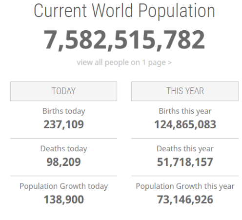

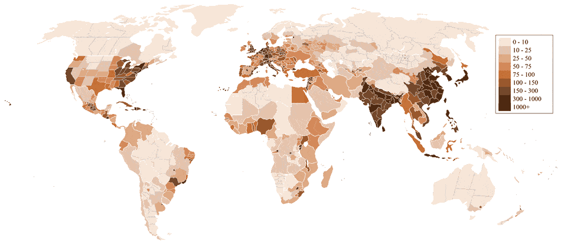

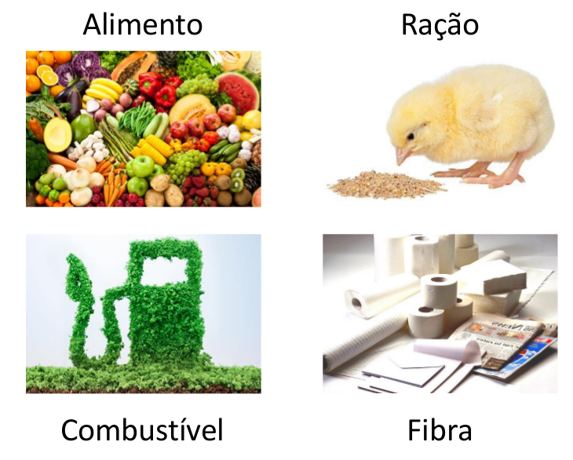

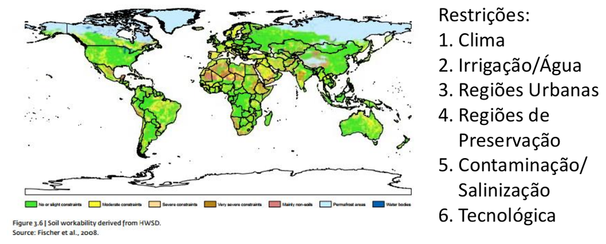

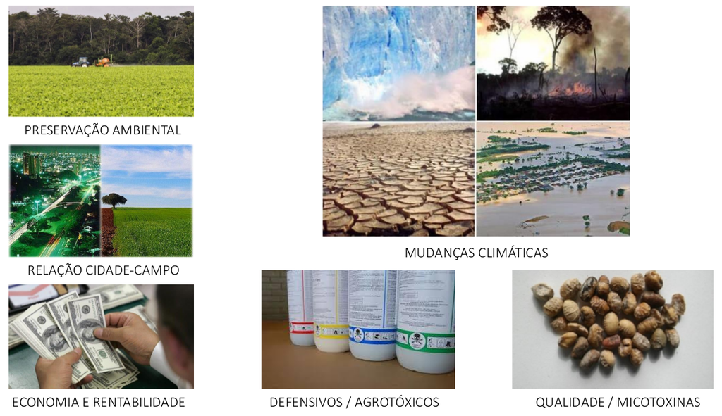

## Como lidar com esses problemas?

- Que tal por meio da genética?

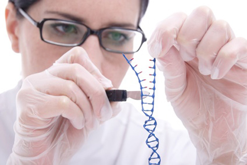

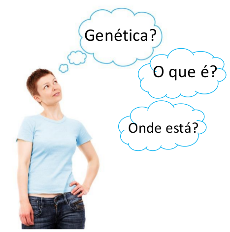

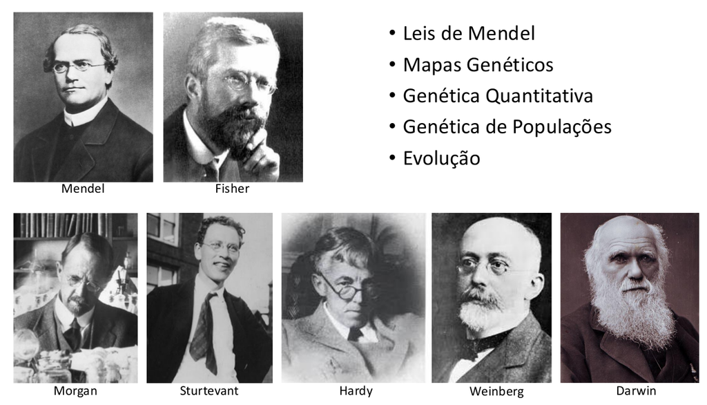

## Domesticação

[video not shown]

## Fenótipo = Genótipo + Ambiente

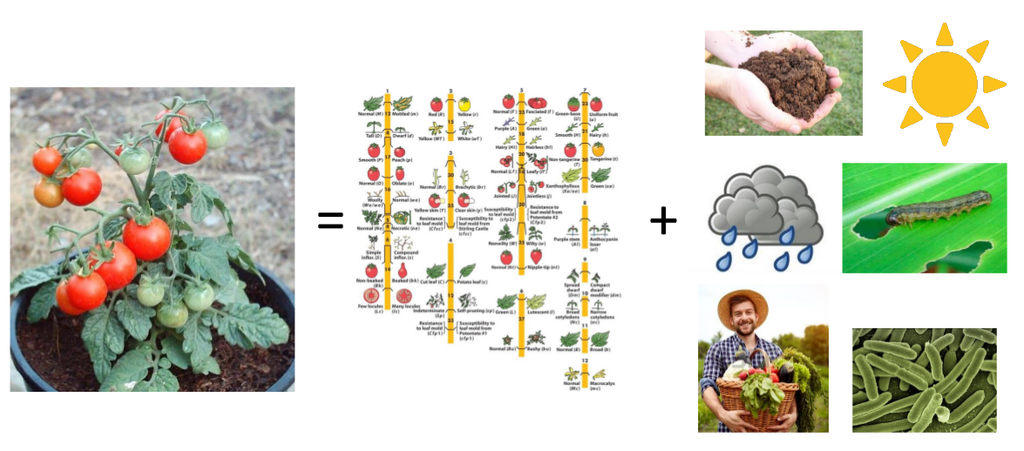

## Fitopatologia e Resistência Genética

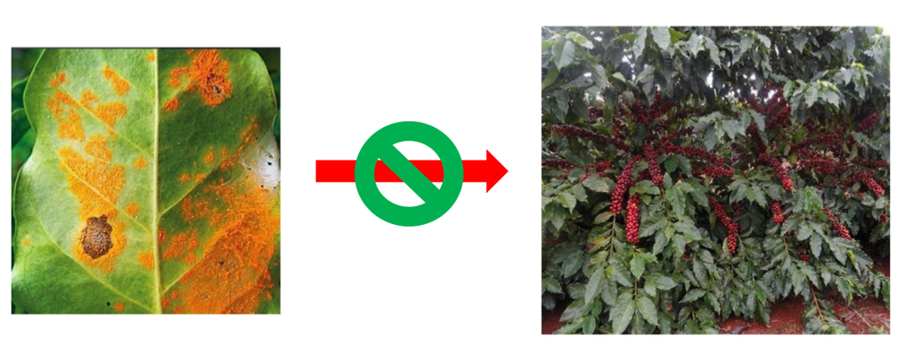

## Ecologia e Populações

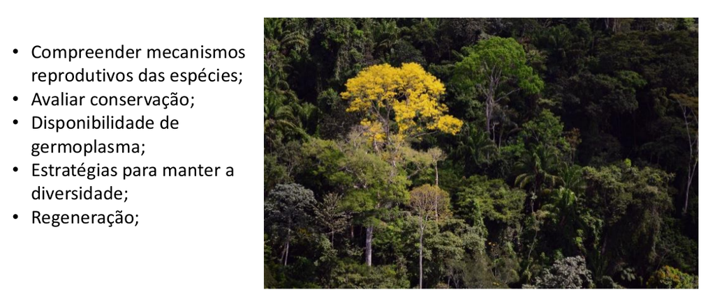

## Zoneameto Climático e Adaptação

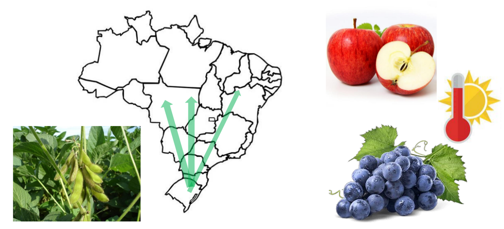

## Economia e Mercado

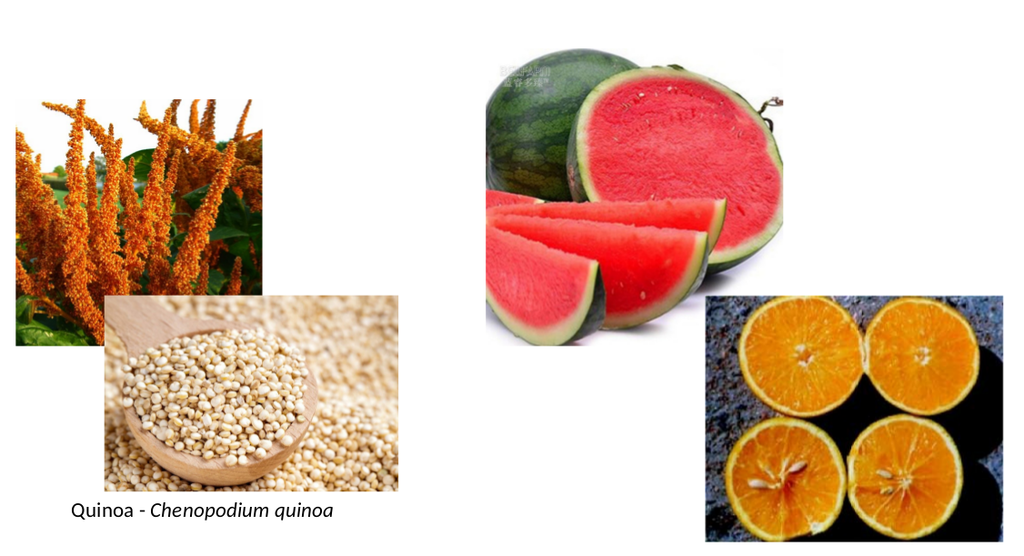

## Fenótipo = Genótipo + Ambiente

[figure not shown]

## Como lidar com tanta informação?

[figure not shown]

## A realidade atual e o futuro

Divergência entre capacidade tecnológicas e aplicação

[You Should Learn to Program: Christian Genco at TEDxSMU](https://www.youtube.com/watch?v=xfBWk4nw440)

- Apollo Guidance Computer (1961) x 1 milhão = Smartphone (hoje)

[figure not shown]

## Linguagem de programação

Nível de abstração das linguagens

- Mais baixo o nível, mais liberdades e mais difícil a aprendizagem
- Big data
- Reprodutibilidade

[figure not shown]

## *Linguagem* de Programação

Curva de aprendizagem

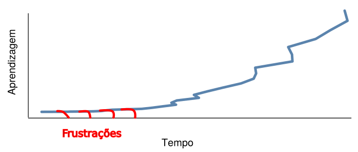

## *Linguagem* de Programação

Lidar com frustrações

[figure not shown]

## *Linguagem* de Programação

Incentivo à lógica de programação

[Hour of Code](https://hourofcode.com/pt)

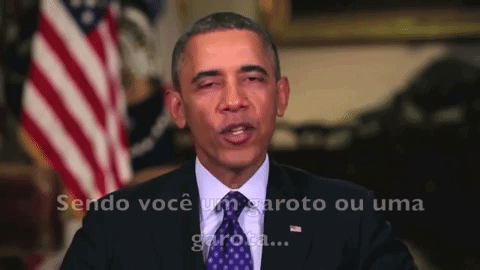

[Scratch](https://scratch.mit.edu/)

[Coursera](https://pt.coursera.org/)

[Khan academy](https://pt.khanacademy.org/)

[Code academy](https://www.codecademy.com/pt)

[Code school](https://www.codeschool.com/)

[edX](https://www.edx.org/)

## *Linguagem* de Programação

Dentre todas, por que o R?

- Popularidade crescente (index de [Tiobe](https://www.tiobe.com/tiobe-index/r/) e [raking IEEE (18 de julho de 2017)](http://spectrum.ieee.org/static/interactive-the-top-programming-languages-2017))

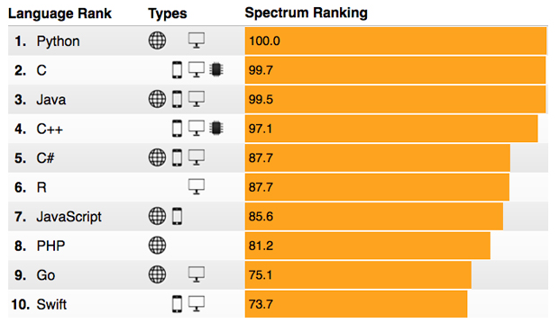

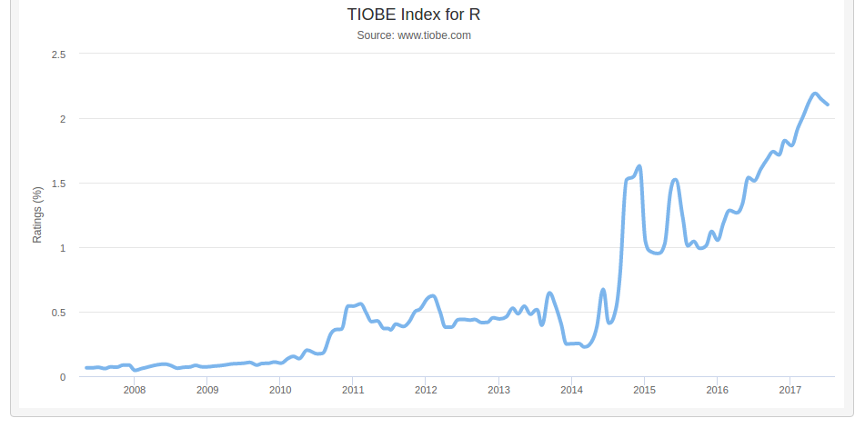

Texto sobre no [R-bloggers](https://www.r-bloggers.com/why-r-is-the-best-data-science-language-to-learn-today/)

## *Linguagem* de Programação

Dentre todas, por que o R?

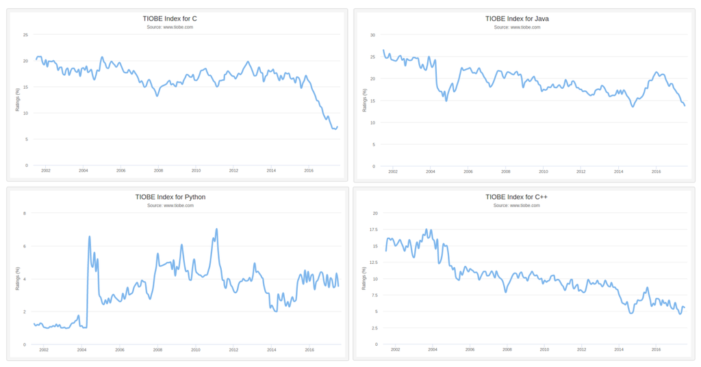

## O que é o R?

*Ambiente* Estatístico

Funcionalidades básicas flexíveis

- Infinitas combinações

Extensível (pacotes):

- [CRAN](https://cran.r-project.org/index.html) (11076 pacotes em 16.07.2017)
- [Bioconductor](https://bioconductor.org/) (1383 pacotes em 16.07.2017)
- [Github](https://github.com/)

## Algumas capacidades

- Compatibilidade com qualquer plataforma
- Várias possibilidades de manipulação de dados
- Processamento rápido
- Lida bem com Big Data
- Automação e reprodutibilidade
- Relatórios e Apresentações (inclusive esta e as próximas)
- Estado da arte em gráficos ( [belos exemplos](http://www.r-graph-gallery.com/) )
- …

## *Linguagem* de Programação

Materiais disponíveis para aprendizagem de R

Algumas sugestões:

- Manuais do [CRAN](https://cran.r-project.org/)
- Pacote interativo [Swirl](http://swirlstats.com/students.html)
- Canal do Youtube [The New Boston](https://www.youtube.com/playlist?list=PL6gx4Cwl9DGCzVMGCPi1kwvABu7eWv08P)
- Cursos do [Datacamp](https://www.datacamp.com/community/open-courses)
- Série de tarefas em [TryR](http://tryr.codeschool.com/)

## *Software Livre*

[figure not shown]

Free Software Foundation’s GNU general license:

- Rodar o programa para qualquer propósito
- Estudar como o programa funciona e adaptar isso aos seus interesses
- Distribuir cópias
- Aprimorar o programa e liberar para a comunidade acesso ao código fonte

## *Software Livre*

Poder da mentalidade colaborativa: [Github](https://github.com/)

[Impacto social](https://github.com/showcases/social-impact)

- [Free, easy-to-use software for developing world healthcare](http://hospitalrun.io/) - 90 contribuidores

[Ciência](https://github.com/showcases/science)

- [Cmssw](https://github.com/cms-sw/cmssw) - Partículas elementares Higgs Boson (2012), 3800 pessoas de 42 países diferentes, 645 contribuidores no github
- [Khmer](https://github.com/dib-lab/khmer) - 63 contribuidores
- [OneMap](https://github.com/augusto-garcia/onemap) - 7 contribuidores
- [Muitos outros pacotes do R](https://github.com/trending/r)
- Os slides deta aula ([site](https://cristianetaniguti.github.io/aula_genetica/Aula_genetica.html#))- 2 contribuidores

[Tutorial sobre o git](http://augusto-garcia.github.io/statgen-esalq/Short-tutorial-about-Git/)

Para mais motivação:

TED talks:

- [Mitch Resnick: Let's teach kids to code](https://www.youtube.com/watch?v=Ok6LbV6bqaE)
- [Teach girls bravery, not perfection | Reshma Saujani](https://www.youtube.com/watch?v=fC9da6eqaqg)
- [My Experience of Using the Statistical Language R | Nathan Hadjiyski](https://www.youtube.com/watch?v=HtO40PR0fjM)

Vídeos motivadores:

- [Hour of code 1](https://www.youtube.com/watch?v=ip051U7Rvds)
- [Hour of code 2](https://www.youtube.com/watch?v=FC5FbmsH4fw)
- [Incentivo do Obama](https://www.youtube.com/watch?v=6XvmhE1J9PY)